# GLM Final Project

R Gogliotti

March 25, 2019

# Diabetes Data

```r
## Import Data
library(faraway)
data("diabetes")

#fixes class issue that prevents working with data
diabetes[] <- lapply(diabetes, unclass)
```

# EDA

```r
str(diabetes)
```

```
## 'data.frame':    403 obs. of  19 variables:
##  $ id      : int  1000 1001 1002 1003 1005 1008 1011 1015 1016 1022 ...
##   ..- attr(*, "label")= chr "Subject ID"
##  $ chol    : int  203 165 228 78 249 248 195 227 177 263 ...
##   ..- attr(*, "label")= chr "Total Cholesterol"
##  $ stab.glu: int  82 97 92 93 90 94 92 75 87 89 ...
##   ..- attr(*, "label")= chr "Stabilized Glucose"
##  $ hdl     : int  56 24 37 12 28 69 41 44 49 40 ...
##   ..- attr(*, "label")= chr "High Density Lipoprotein"
##  $ ratio   : num  3.6 6.9 6.2 6.5 8.9 ...
##   ..- attr(*, "label")= chr "Cholesterol/HDL Ratio"
##  $ glyhb   : num  4.31 4.44 4.64 4.63 7.72 ...
##   ..- attr(*, "label")= chr "Glycosolated Hemoglobin"
##  $ location: int  1 1 1 1 1 1 1 1 1 1 ...
##   ..- attr(*, "levels")= chr  "Buckingham" "Louisa"
##  $ age     : int  46 29 58 67 64 34 30 37 45 55 ...
##   ..- attr(*, "units")= chr "years"
##  $ gender  : int  2 2 2 1 1 1 1 1 1 2 ...
##   ..- attr(*, "levels")= chr  "male" "female"
##  $ height  : int  62 64 61 67 68 71 69 59 69 63 ...
##   ..- attr(*, "units")= chr "inches"
##  $ weight  : int  121 218 256 119 183 190 191 170 166 202 ...
##   ..- attr(*, "units")= chr "pounds"
##  $ frame   : int  2 3 3 3 2 3 2 2 3 1 ...
##   ..- attr(*, "levels")= chr  "small" "medium" "large"
##  $ bp.1s   : int  118 112 190 110 138 132 161 NA 160 108 ...
##   ..- attr(*, "label")= chr "First Systolic Blood Pressure"
##  $ bp.1d   : int  59 68 92 50 80 86 112 NA 80 72 ...
##   ..- attr(*, "label")= chr "First Diastolic Blood Pressure"
##  $ bp.2s   : int  NA NA 185 NA NA NA 161 NA 128 NA ...
##   ..- attr(*, "label")= chr "Second Systolic Blood Pressure"
##   ..- attr(*, "comment")= chr "equals first measurement if it was not high"
##  $ bp.2d   : int  NA NA 92 NA NA NA 112 NA 86 NA ...
##   ..- attr(*, "comment")= chr "equals first measurement if it was not high"
##   ..- attr(*, "label")= chr "Second Diastolic Blood Pressure"
##  $ waist   : int  29 46 49 33 44 36 46 34 34 45 ...
##   ..- attr(*, "units")= chr "inches"
##  $ hip     : int  38 48 57 38 41 42 49 39 40 50 ...
##   ..- attr(*, "units")= chr "inches"
##  $ time.ppn: int  720 360 180 480 300 195 720 1020 300 240 ...
##   ..- attr(*, "label")= chr "Postprandial Time when Labs were Drawn"
##   ..- attr(*, "units")= chr "minutes"
```

```r
summary(diabetes)
```

```
##        id             chol          stab.glu          hdl
##  Min.   : 1000   Min.   : 78.0   Min.   : 48.0   Min.   : 12.00
##  1st Qu.: 4792   1st Qu.:179.0   1st Qu.: 81.0   1st Qu.: 38.00
##  Median :15766   Median :204.0   Median : 89.0   Median : 46.00
##  Mean   :15978   Mean   :207.8   Mean   :106.7   Mean   : 50.45
##  3rd Qu.:20336   3rd Qu.:230.0   3rd Qu.:106.0   3rd Qu.: 59.00
##  Max.   :41756   Max.   :443.0   Max.   :385.0   Max.   :120.00
##                  NA's   :1                       NA's   :1
##      ratio            glyhb          location          age
##  Min.   : 1.500   Min.   : 2.68   Min.   :1.000   Min.   :19.00
##  1st Qu.: 3.200   1st Qu.: 4.38   1st Qu.:1.000   1st Qu.:34.00
##  Median : 4.200   Median : 4.84   Median :2.000   Median :45.00
##  Mean   : 4.522   Mean   : 5.59   Mean   :1.504   Mean   :46.85
##  3rd Qu.: 5.400   3rd Qu.: 5.60   3rd Qu.:2.000   3rd Qu.:60.00
##  Max.   :19.300   Max.   :16.11   Max.   :2.000   Max.   :92.00
##  NA's   :1        NA's   :13
##      gender          height          weight          frame
##  Min.   :1.000   Min.   :52.00   Min.   : 99.0   Min.   :1.000
##  1st Qu.:1.000   1st Qu.:63.00   1st Qu.:151.0   1st Qu.:1.000
##  Median :2.000   Median :66.00   Median :172.5   Median :2.000
##  Mean   :1.581   Mean   :66.02   Mean   :177.6   Mean   :1.997
##  3rd Qu.:2.000   3rd Qu.:69.00   3rd Qu.:200.0   3rd Qu.:3.000
##  Max.   :2.000   Max.   :76.00   Max.   :325.0   Max.   :3.000
##                  NA's   :5       NA's   :1       NA's   :12
##      bp.1s           bp.1d            bp.2s           bp.2d
##  Min.   : 90.0   Min.   : 48.00   Min.   :110.0   Min.   : 60.00
##  1st Qu.:121.2   1st Qu.: 75.00   1st Qu.:138.0   1st Qu.: 84.00
##  Median :136.0   Median : 82.00   Median :149.0   Median : 92.00
##  Mean   :136.9   Mean   : 83.32   Mean   :152.4   Mean   : 92.52
##  3rd Qu.:146.8   3rd Qu.: 90.00   3rd Qu.:161.0   3rd Qu.:100.00
##  Max.   :250.0   Max.   :124.00   Max.   :238.0   Max.   :124.00
##  NA's   :5       NA's   :5        NA's   :262     NA's   :262
##      waist           hip           time.ppn
##  Min.   :26.0   Min.   :30.00   Min.   :   5.0
##  1st Qu.:33.0   1st Qu.:39.00   1st Qu.:  90.0
##  Median :37.0   Median :42.00   Median : 240.0
##  Mean   :37.9   Mean   :43.04   Mean   : 341.2
##  3rd Qu.:41.0   3rd Qu.:46.00   3rd Qu.: 517.5
##  Max.   :56.0   Max.   :64.00   Max.   :1560.0
##  NA's   :2      NA's   :2       NA's   :3
```

From the summary we know that some variables have excessive NA’s remove these from data using criteria more than 5% NA’s are dropped.

```r
dbt <- diabetes[,-which(colMeans(is.na(diabetes)) > 0.05)]
summary(dbt)
```

```
##        id             chol          stab.glu          hdl
##  Min.   : 1000   Min.   : 78.0   Min.   : 48.0   Min.   : 12.00
##  1st Qu.: 4792   1st Qu.:179.0   1st Qu.: 81.0   1st Qu.: 38.00
##  Median :15766   Median :204.0   Median : 89.0   Median : 46.00
##  Mean   :15978   Mean   :207.8   Mean   :106.7   Mean   : 50.45
##  3rd Qu.:20336   3rd Qu.:230.0   3rd Qu.:106.0   3rd Qu.: 59.00
##  Max.   :41756   Max.   :443.0   Max.   :385.0   Max.   :120.00
##                  NA's   :1                       NA's   :1
##      ratio            glyhb          location          age
##  Min.   : 1.500   Min.   : 2.68   Min.   :1.000   Min.   :19.00
##  1st Qu.: 3.200   1st Qu.: 4.38   1st Qu.:1.000   1st Qu.:34.00
##  Median : 4.200   Median : 4.84   Median :2.000   Median :45.00
##  Mean   : 4.522   Mean   : 5.59   Mean   :1.504   Mean   :46.85
##  3rd Qu.: 5.400   3rd Qu.: 5.60   3rd Qu.:2.000   3rd Qu.:60.00
##  Max.   :19.300   Max.   :16.11   Max.   :2.000   Max.   :92.00
##  NA's   :1        NA's   :13
##      gender          height          weight          frame
##  Min.   :1.000   Min.   :52.00   Min.   : 99.0   Min.   :1.000
##  1st Qu.:1.000   1st Qu.:63.00   1st Qu.:151.0   1st Qu.:1.000
##  Median :2.000   Median :66.00   Median :172.5   Median :2.000
##  Mean   :1.581   Mean   :66.02   Mean   :177.6   Mean   :1.997
##  3rd Qu.:2.000   3rd Qu.:69.00   3rd Qu.:200.0   3rd Qu.:3.000
##  Max.   :2.000   Max.   :76.00   Max.   :325.0   Max.   :3.000
##                  NA's   :5       NA's   :1       NA's   :12
##      bp.1s           bp.1d            waist           hip
##  Min.   : 90.0   Min.   : 48.00   Min.   :26.0   Min.   :30.00
##  1st Qu.:121.2   1st Qu.: 75.00   1st Qu.:33.0   1st Qu.:39.00
##  Median :136.0   Median : 82.00   Median :37.0   Median :42.00
##  Mean   :136.9   Mean   : 83.32   Mean   :37.9   Mean   :43.04
##  3rd Qu.:146.8   3rd Qu.: 90.00   3rd Qu.:41.0   3rd Qu.:46.00
##  Max.   :250.0   Max.   :124.00   Max.   :56.0   Max.   :64.00
##  NA's   :5       NA's   :5        NA's   :2      NA's   :2
##     time.ppn
##  Min.   :   5.0
##  1st Qu.:  90.0
##  Median : 240.0
##  Mean   : 341.2
##  3rd Qu.: 517.5
##  Max.   :1560.0
##  NA's   :3
```

```r
dbt <- as.data.frame(dbt)
```

```r
#convert to binary variables
dbt$diagnosis <- ifelse(dbt$glyhb > 7, 1,0)

dbt$diagnosis <- as.factor(dbt$diagnosis)

#response variable summary
table(dbt$diagnosis)
```

```
##
##   0   1
## 330  60
```

```r
library(tidyverse)
```

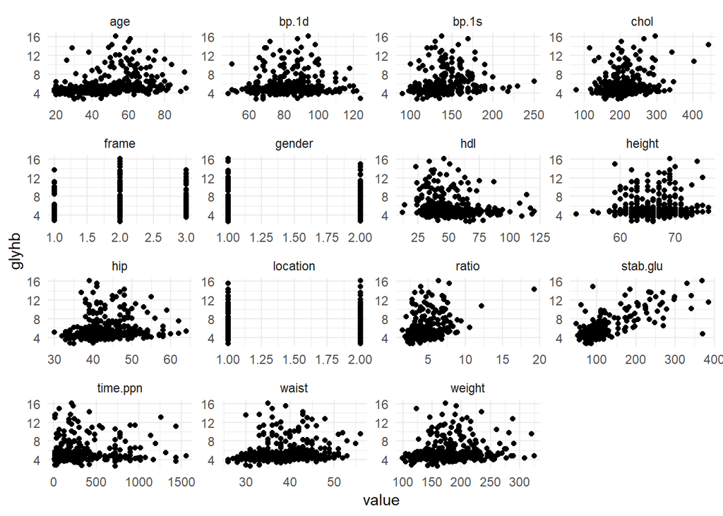

```r
subset(dbt,select=-c(id, diagnosis)) %>%
  gather(-glyhb, key = "var_name", value = "value") %>%
  ggplot(aes(x = value, y = glyhb)) +
  geom_point() +
  facet_wrap(~ var_name, scales = "free") +
  theme_minimal()
```

```r
# remove glyhb because it can not be used in prediction
dbt <- subset(dbt, select= -c(glyhb))

# remove id because it can not be used in prediction
dbt <- subset(dbt, select= -c(id))

# remove time.ppn because it refers to when a lab was drawn which is not a likely predictor for if someone has a chronic condition. This variable is important for blood glucose monitoring.
dbt <- subset(dbt, select= -c(time.ppn))

# remove location because it can not be used to apply to a broader population
dbt <- subset(dbt, select= -c(location))

#correct frame not being read as factor
dbt$frame <- as.factor(as.character(dbt$frame))

#correct gender not being read as factor
dbt$gender <- as.factor(as.character(dbt$gender))
str(dbt)
```

```
## 'data.frame':    403 obs. of  14 variables:
##  $ chol     : int  203 165 228 78 249 248 195 227 177 263 ...
##  $ stab.glu : int  82 97 92 93 90 94 92 75 87 89 ...
##  $ hdl      : int  56 24 37 12 28 69 41 44 49 40 ...
##  $ ratio    : num  3.6 6.9 6.2 6.5 8.9 ...
##  $ age      : int  46 29 58 67 64 34 30 37 45 55 ...
##  $ gender   : Factor w/ 2 levels "1","2": 2 2 2 1 1 1 1 1 1 2 ...
##  $ height   : int  62 64 61 67 68 71 69 59 69 63 ...
##  $ weight   : int  121 218 256 119 183 190 191 170 166 202 ...
##  $ frame    : Factor w/ 3 levels "1","2","3": 2 3 3 3 2 3 2 2 3 1 ...
##  $ bp.1s    : int  118 112 190 110 138 132 161 NA 160 108 ...
##  $ bp.1d    : int  59 68 92 50 80 86 112 NA 80 72 ...
##  $ waist    : int  29 46 49 33 44 36 46 34 34 45 ...
##  $ hip      : int  38 48 57 38 41 42 49 39 40 50 ...
##  $ diagnosis: Factor w/ 2 levels "0","1": 1 1 1 1 2 1 1 1 1 1 ...
```

```r
#remove NAs
dbt <- na.omit(dbt)
table(dbt$diagnosis)
```

```
##
##   0   1
## 311  56
```

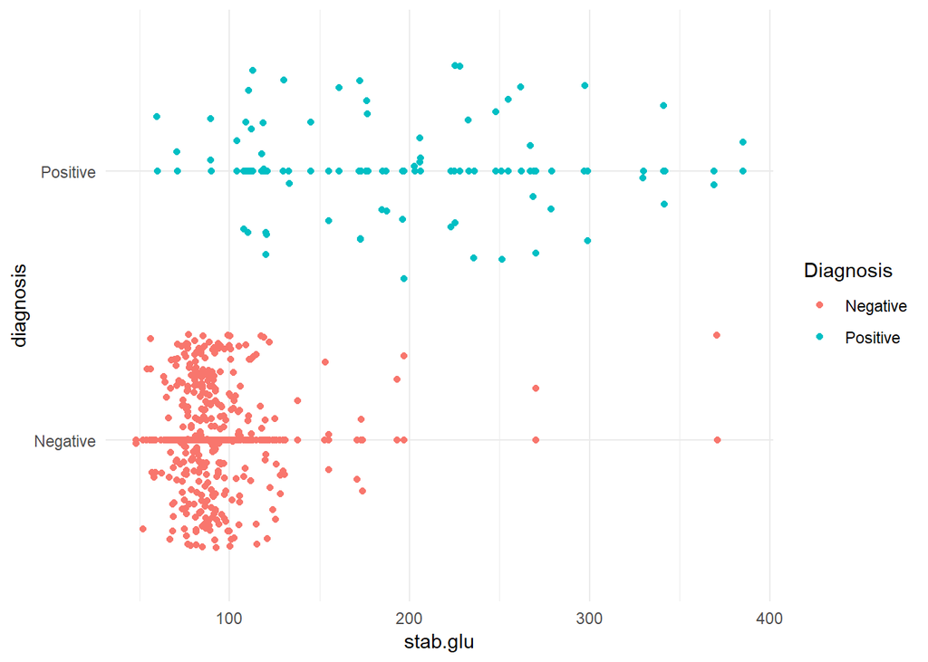

```r
dbt2 <- dbt
dbt2$diagnosis <- ifelse(dbt2$diagnosis==1,"Positive","Negative")
ggplot(dbt2, aes(x=stab.glu, y=diagnosis,color=diagnosis)) +geom_point()+ geom_jitter()+  theme_minimal() +
  labs(color = "Diagnosis")
```

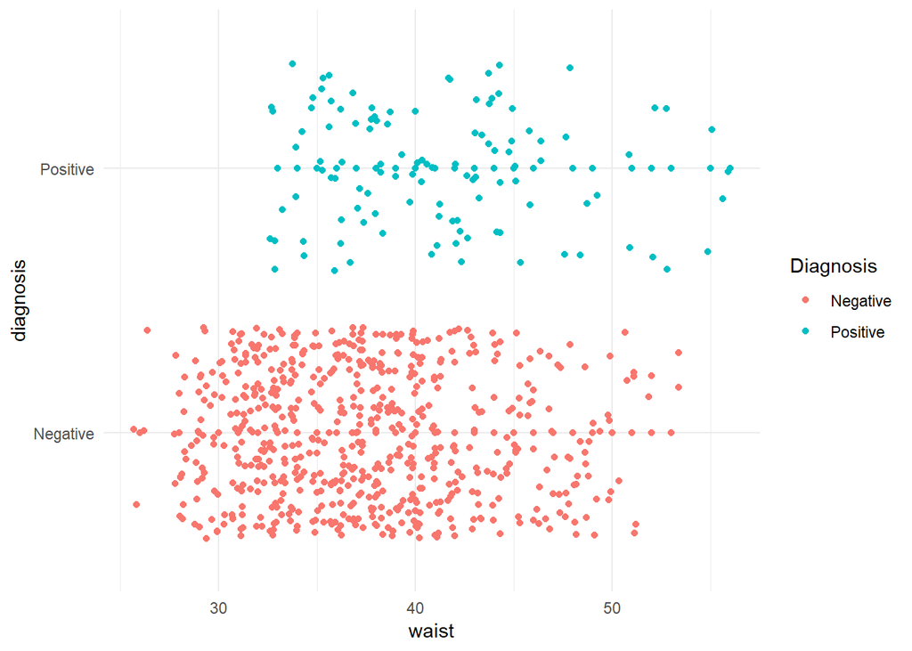

```r
ggplot(dbt2, aes(x=waist, y=diagnosis, color=diagnosis)) +geom_point()+ geom_jitter()+ geom_jitter()+  theme_minimal() +
  labs(color = "Diagnosis")
```

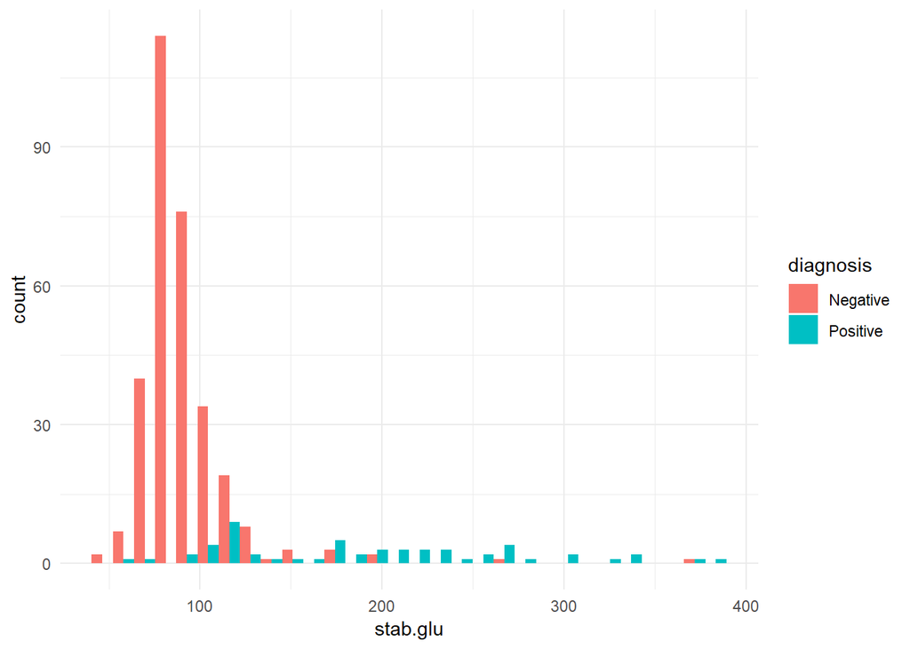

```r
ggplot(dbt2, aes(x=stab.glu, fill=diagnosis)) +geom_histogram(bins = 30, position="dodge")+
  theme(legend.position="top")+scale_color_brewer(palette="Dark2")+  theme_minimal()
```

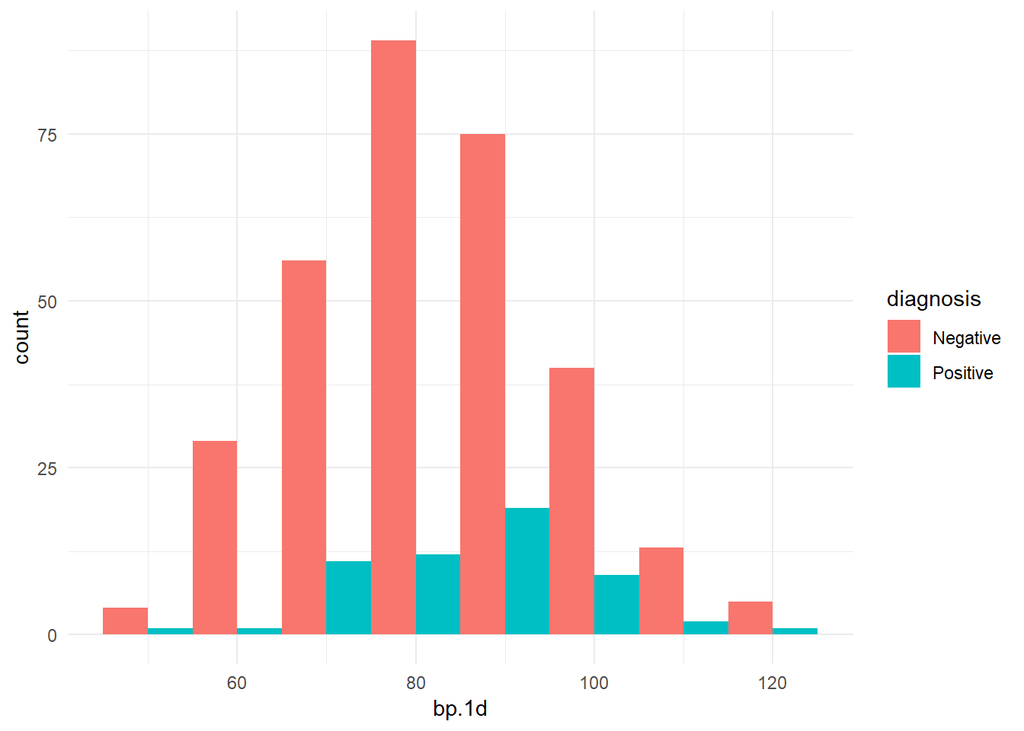

```r
ggplot(dbt2, aes(x=bp.1d,  fill=diagnosis)) +geom_histogram(binwidth = 10, position="dodge")+
  theme(legend.position="top")+scale_color_brewer(palette="Dark2") + theme_minimal()
```

##step 2: Variable Selection

```r
full <- glm(diagnosis~.,family=binomial, data=dbt)
summary(full)
```

```
##
## Call:
## glm(formula = diagnosis ~ ., family = binomial, data = dbt)
##
## Deviance Residuals:
##     Min       1Q   Median       3Q      Max
## -3.6415  -0.3444  -0.2173  -0.1170   3.3647
##
## Coefficients:
##              Estimate Std. Error z value Pr(>|z|)
## (Intercept) -6.974692   6.651932  -1.049   0.2944
## chol         0.013303   0.008972   1.483   0.1382
## stab.glu     0.034530   0.005324   6.486 8.83e-11 ***
## hdl         -0.041416   0.032302  -1.282   0.1998
## ratio       -0.205229   0.283196  -0.725   0.4686
## age          0.034116   0.018325   1.862   0.0626 .
## gender2      0.212599   0.708617   0.300   0.7642
## height      -0.060518   0.086051  -0.703   0.4819
## weight       0.002973   0.013386   0.222   0.8242
## frame2      -0.117902   0.616096  -0.191   0.8482
## frame3      -0.426204   0.749493  -0.569   0.5696
## bp.1s        0.005218   0.012216   0.427   0.6693
## bp.1d        0.012549   0.021527   0.583   0.5599
## waist        0.072431   0.080237   0.903   0.3667
## hip         -0.040285   0.080083  -0.503   0.6149
## ---
## Signif. codes:  0 '***' 0.001 '**' 0.01 '*' 0.05 '.' 0.1 ' ' 1
##
## (Dispersion parameter for binomial family taken to be 1)
##
##     Null deviance: 313.55  on 366  degrees of freedom
## Residual deviance: 157.83  on 352  degrees of freedom
## AIC: 187.83
##
## Number of Fisher Scoring iterations: 6
```

```r
#perform variable selection based on AIC
step <- step(full)
```

```
## Start:  AIC=187.83
## diagnosis ~ chol + stab.glu + hdl + ratio + age + gender + height +
##     weight + frame + bp.1s + bp.1d + waist + hip
##
##            Df Deviance    AIC
## - frame     2   158.24 184.24
## - weight    1   157.88 185.88
## - gender    1   157.92 185.92
## - bp.1s     1   158.01 186.01
## - hip       1   158.08 186.08
## - bp.1d     1   158.17 186.17
## - height    1   158.31 186.31
## - ratio     1   158.32 186.32
## - waist     1   158.64 186.64
## - hdl       1   159.55 187.55
## <none>          157.83 187.83
## - chol      1   160.02 188.02
## - age       1   161.41 189.41
## - stab.glu  1   248.32 276.32
##
## Step:  AIC=184.24
## diagnosis ~ chol + stab.glu + hdl + ratio + age + gender + height +
##     weight + bp.1s + bp.1d + waist + hip
##
##            Df Deviance    AIC
## - weight    1   158.26 182.26
## - bp.1s     1   158.37 182.37
## - hip       1   158.47 182.47
## - gender    1   158.50 182.50
## - height    1   158.59 182.59
## - bp.1d     1   158.63 182.63
## - ratio     1   158.70 182.70
## - waist     1   158.92 182.92
## - hdl       1   159.88 183.88
## <none>          158.24 184.24
## - chol      1   160.49 184.49
## - age       1   161.56 185.56
## - stab.glu  1   248.91 272.91
##
## Step:  AIC=182.26
```

[output cut: 95 more lines]

```
## <none>          161.96 173.96
## - waist     1   164.00 174.00
## - chol      1   166.26 176.26
## - age       1   168.61 178.61
## - stab.glu  1   251.55 261.55
##
## Step:  AIC=173.4
## diagnosis ~ chol + stab.glu + age + waist
##
##            Df Deviance    AIC
## <none>          163.40 173.40
## - waist     1   166.41 174.41
## - chol      1   166.97 174.97
## - age       1   169.64 177.64
## - stab.glu  1   261.17 269.17
```

Selects formula diagnosis ~ chol + stab.glu + age + waist

```r
#binary reduced model fit
reduced <- glm(diagnosis ~chol + stab.glu + age + waist,family=binomial, data=dbt )
summary(reduced)
```

```
##
## Call:
## glm(formula = diagnosis ~ chol + stab.glu + age + waist, family = binomial,
##     data = dbt)
##
## Deviance Residuals:
##     Min       1Q   Median       3Q      Max
## -3.5288  -0.3619  -0.2361  -0.1418   3.1621
##
## Coefficients:
##               Estimate Std. Error z value Pr(>|z|)
## (Intercept) -11.807894   1.992747  -5.925 3.11e-09 ***
## chol          0.008706   0.004876   1.786   0.0741 .
## stab.glu      0.032856   0.004779   6.875 6.22e-12 ***
## age           0.033827   0.013709   2.468   0.0136 *
## waist         0.062086   0.035604   1.744   0.0812 .
## ---
## Signif. codes:  0 '***' 0.001 '**' 0.01 '*' 0.05 '.' 0.1 ' ' 1
##
## (Dispersion parameter for binomial family taken to be 1)
##
##     Null deviance: 313.55  on 366  degrees of freedom
## Residual deviance: 163.40  on 362  degrees of freedom
## AIC: 173.4
##
## Number of Fisher Scoring iterations: 6
```

check for outliers

```r
cook <-abs(cooks.distance(reduced))
which(cook>1)
```

```
## named integer(0)
```

```r
# no outliers found
```

## Step 3 Assess Model Fit

### Assess Model assumtions

#### plot Loess plots

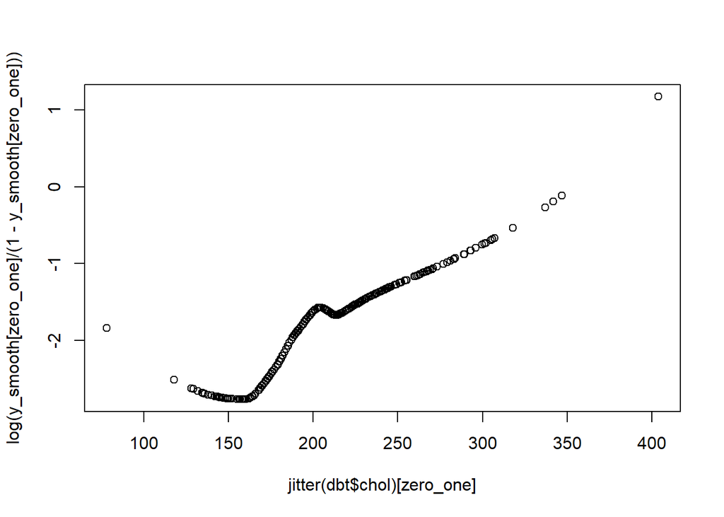

```r
##Loess for chol
dbt$diagnosis <- as.numeric(as.character(dbt$diagnosis))
#Obtain y_bar, smoothed responses using the loess function
y_smooth <- predict(loess(as.numeric(diagnosis) ~chol, data = dbt))
#Which values of y_bar are less than zero or greater than one?
zero_one <- which(y_smooth>0 & y_smooth<1)
#Make plot of X, y_bar for observations with y_bar in (0,1)
plot(jitter(dbt$chol)[zero_one], log(y_smooth[zero_one]/(1-y_smooth[zero_one])))
```

Above we see close to linear. Chol does not need to be modified with a spline.

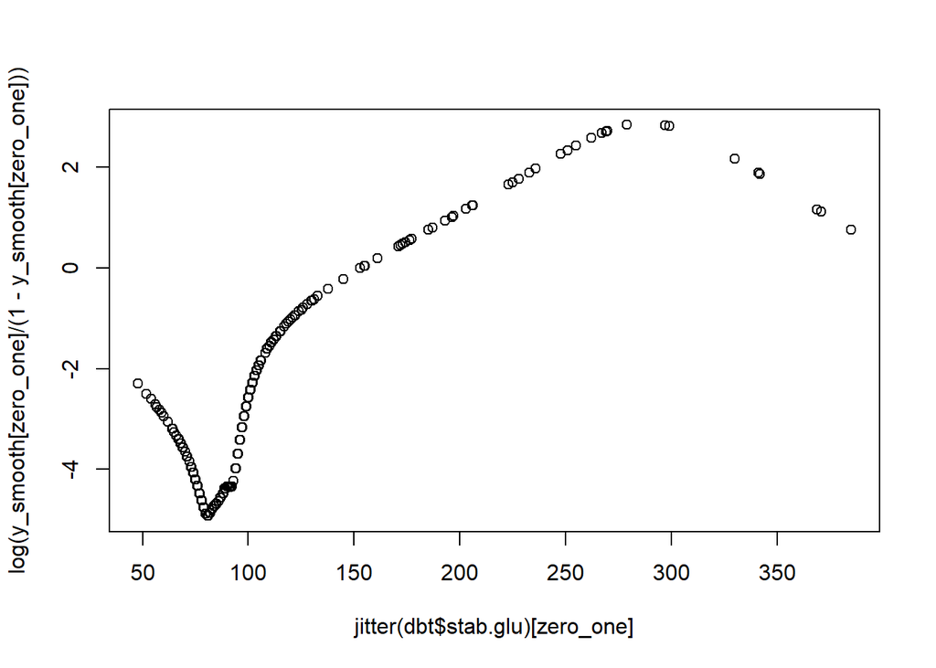

```r
##Loess for stab.glu
#Obtain y_bar, smoothed responses using the loess function
y_smooth <- predict(loess(diagnosis ~stab.glu , data = dbt))
#Which values of y_bar are less than zero or greater than one?
zero_one <- which(y_smooth>0 & y_smooth<1)
#Make plot of X, y_bar for observations with y_bar in (0,1)
plot(jitter(dbt$stab.glu)[zero_one], log(y_smooth[zero_one]/(1-y_smooth[zero_one])))
```

Above we seen not linear. Stab.glu needs to be modified with a spline.

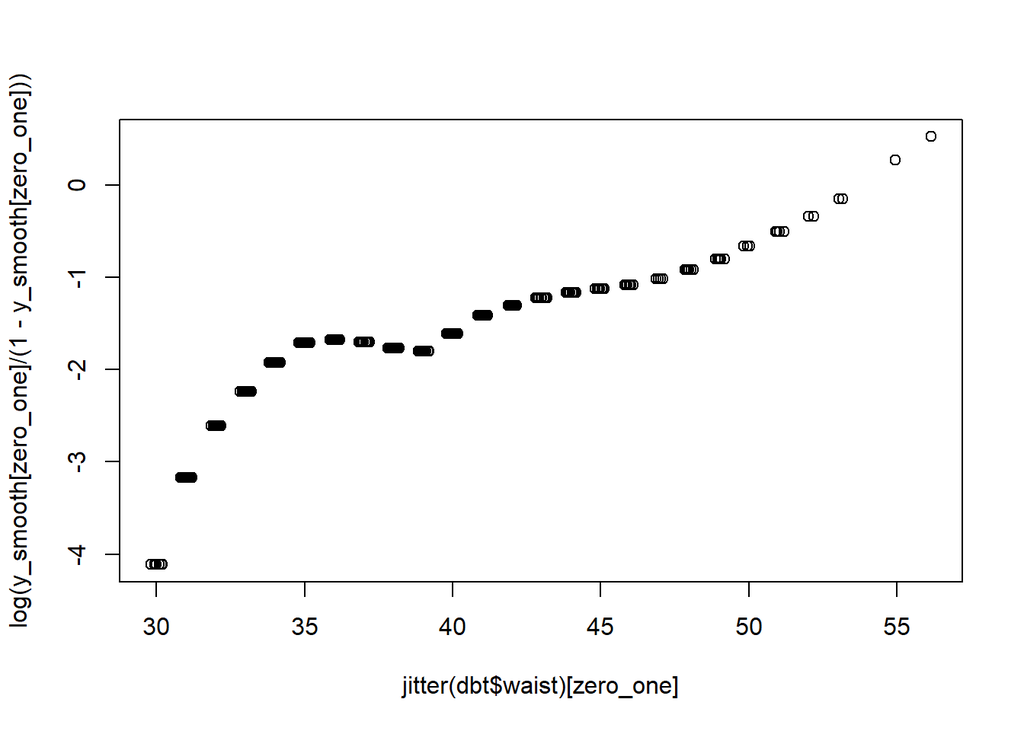

```r
##Loess for waist
#Obtain y_bar, smoothed responses using the loess function
y_smooth <- predict(loess(diagnosis ~ waist, data = dbt))
#Which values of y_bar are less than zero or greater than one?
zero_one <- which(y_smooth>0 & y_smooth<1)
#Make plot of X, y_bar for observations with y_bar in (0,1)
plot(jitter(dbt$waist)[zero_one], log(y_smooth[zero_one]/(1-y_smooth[zero_one])))
```

This appears fairly linear and thus waist does not need a spline

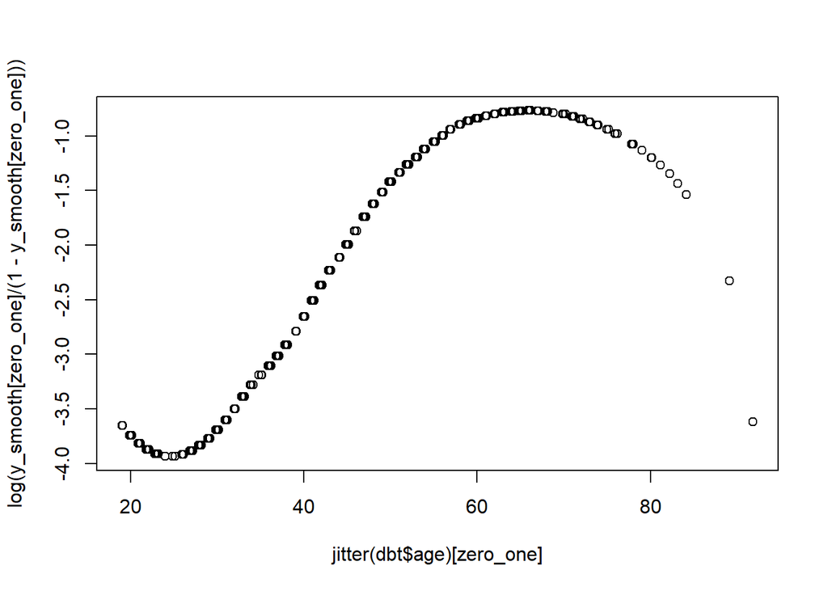

```r
##Loess for age
y_smooth <- predict(loess(diagnosis ~ age, data = dbt))
#Which values of y_bar are less than zero or greater than one?
zero_one <- which(y_smooth>0 & y_smooth<1)
#Make plot of X, y_bar for observations with y_bar in (0,1)
plot(jitter(dbt$age)[zero_one], log(y_smooth[zero_one]/(1-y_smooth[zero_one])))
```

The above plot is non-linear; therefore age will require a spline adjustment.

```r
##function to create splines, x is predictor, k is vector of knots. Can only do k=3 knots
my.4splines <- function(x,k){
  k1 <- k[1]
  k2 <- k[2]
  k3 <- k[3]
  x.l1 <- NULL
  x.l2 <- NULL
  x.l3 <- NULL
  x.l4 <- NULL
  for (i in 1:length(x)){
    x.l1[i] <- min(x[i],k1)
    x.l2[i] <- max(min(x[i],k2),k1)-k1
    x.l3[i] <- max(min(x[i],k3),k2)-k2
    x.l4[i] <- max(x[i],k3)-k3
  }
  x.s <- cbind(x.l1,x.l2,x.l3,x.l4)
}
```

```r
#Find knots for age and stab.glu
knots_age <- quantile(dbt$age,c(.10,.50,.90))
knots_stab.glu <- quantile(dbt$stab.glu,c(.10,.50,.90))
#Create splines for age and bmi
age_spline <- my.4splines(dbt$age,knots_age)
stab.glu_spline <- my.4splines(dbt$stab.glu,knots_stab.glu)


#Put both sets of splines in a model
reduced2 <- glm(diagnosis~age_spline  +stab.glu_spline + waist + chol ,data=dbt,family=binomial)
summary(reduced2)
```

```
##
## Call:
## glm(formula = diagnosis ~ age_spline + stab.glu_spline + waist +
##     chol, family = binomial, data = dbt)
##
## Deviance Residuals:
##     Min       1Q   Median       3Q      Max
## -2.5269  -0.3127  -0.1736  -0.0687   2.8315
##
## Coefficients:
##                       Estimate Std. Error z value Pr(>|z|)
## (Intercept)         -3.116e+02  2.445e+04  -0.013   0.9898
## age_splinex.l1       1.196e+01  9.403e+02   0.013   0.9899
## age_splinex.l2       2.454e-02  6.175e-02   0.397   0.6911
## age_splinex.l3       5.462e-02  3.424e-02   1.595   0.1106
## age_splinex.l4      -8.479e-02  7.939e-02  -1.068   0.2855
## stab.glu_splinex.l1 -1.152e-01  8.642e-02  -1.334   0.1823
## stab.glu_splinex.l2  9.216e-02  8.484e-02   1.086   0.2774
## stab.glu_splinex.l3  5.254e-02  9.685e-03   5.424 5.82e-08 ***
## stab.glu_splinex.l4  4.318e-03  7.313e-03   0.590   0.5549
## waist                4.252e-02  3.784e-02   1.124   0.2612
## chol                 1.023e-02  5.468e-03   1.871   0.0614 .
## ---
## Signif. codes:  0 '***' 0.001 '**' 0.01 '*' 0.05 '.' 0.1 ' ' 1
##
## (Dispersion parameter for binomial family taken to be 1)
##
##     Null deviance: 313.55  on 366  degrees of freedom
## Residual deviance: 146.72  on 356  degrees of freedom
## AIC: 168.72
##
## Number of Fisher Scoring iterations: 19
```

```r
library(ResourceSelection)
```

```
## ResourceSelection 0.3-4   2019-01-08
```

```r
hl_test2 <- hoslem.test(dbt$diagnosis,reduced2$fitted.values,10)
hl_test2
```

```
##
##  Hosmer and Lemeshow goodness of fit (GOF) test
##
## data:  dbt$diagnosis, reduced2$fitted.values
## X-squared = 5.6729, df = 8, p-value = 0.6838
```

```r
#verify p-value
pchisq(5.6729,8,lower.tail = F)
```

```
## [1] 0.683818
```

```r
#from p-value we fail to reject
# tells us the model fit is adequate
```

passed

# week 4 model interference

```r
cook <-abs( cooks.distance(reduced2))
which(cook>1)
```

```
## named integer(0)
```

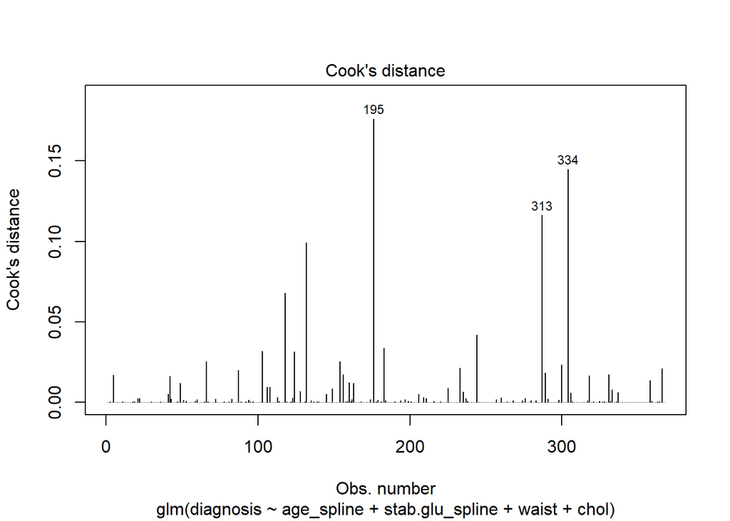

```r
#no outliers found
plot(reduced2, which = 4)
```

It was noted that the new model many of the slopes have a high p-value indicating they may not be significant. A nested models test was run with a smaller model that removes the waist and splined age variables

```r
reduced3 <- glm(diagnosis~stab.glu_spline + chol ,data=dbt,family=binomial)
summary(reduced3)
```

```
##
## Call:
## glm(formula = diagnosis ~ stab.glu_spline + chol, family = binomial,
##     data = dbt)
##
## Deviance Residuals:
##     Min       1Q   Median       3Q      Max
## -2.5723  -0.3385  -0.2044  -0.1163   3.0888
##
## Coefficients:
##                      Estimate Std. Error z value Pr(>|z|)
## (Intercept)          2.473228   5.822340   0.425   0.6710
## stab.glu_splinex.l1 -0.138134   0.088814  -1.555   0.1199
## stab.glu_splinex.l2  0.119133   0.086853   1.372   0.1702
## stab.glu_splinex.l3  0.056770   0.009184   6.181 6.35e-10 ***
## stab.glu_splinex.l4  0.003718   0.006974   0.533   0.5940
## chol                 0.012428   0.005293   2.348   0.0189 *
## ---
## Signif. codes:  0 '***' 0.001 '**' 0.01 '*' 0.05 '.' 0.1 ' ' 1
##
## (Dispersion parameter for binomial family taken to be 1)
##
##     Null deviance: 313.55  on 366  degrees of freedom
## Residual deviance: 155.37  on 361  degrees of freedom
## AIC: 167.37
##
## Number of Fisher Scoring iterations: 7
```

```r
G <- reduced3$deviance-reduced2$deviance
pchisq(G, 365-361, lower.tail = FALSE)
```

```
## [1] 0.07034797
```

```r
#confidence intervals for splines are meaningless
library(MASS)
#for chol
suppressMessages(confint(reduced2, 'chol', level=0.95))
```

```
##        2.5 %       97.5 %
## 0.0001510338 0.0215135506
```

```r
summary(reduced2)$coefficients[11,4]
```

```
## [1] 0.06138141
```

```r
#for waist

suppressMessages(confint(reduced2, 'waist', level=0.95))
```

```
##       2.5 %      97.5 %
## -0.03213994  0.11727599
```

```r
summary(reduced2)$coefficients[10,4]
```

```
## [1] 0.2611983
```

```r
library(ROCR)
library(rpart)
reduced2
```

```
##
## Call:  glm(formula = diagnosis ~ age_spline + stab.glu_spline + waist +
##     chol, family = binomial, data = dbt)
##
## Coefficients:
##         (Intercept)       age_splinex.l1       age_splinex.l2
##          -3.116e+02            1.196e+01            2.454e-02
##      age_splinex.l3       age_splinex.l4  stab.glu_splinex.l1
##           5.462e-02           -8.479e-02           -1.152e-01
## stab.glu_splinex.l2  stab.glu_splinex.l3  stab.glu_splinex.l4
##           9.216e-02            5.254e-02            4.318e-03
##               waist                 chol
##           4.252e-02            1.023e-02
##
## Degrees of Freedom: 366 Total (i.e. Null);  356 Residual
## Null Deviance:       313.5
## Residual Deviance: 146.7     AIC: 168.7
```

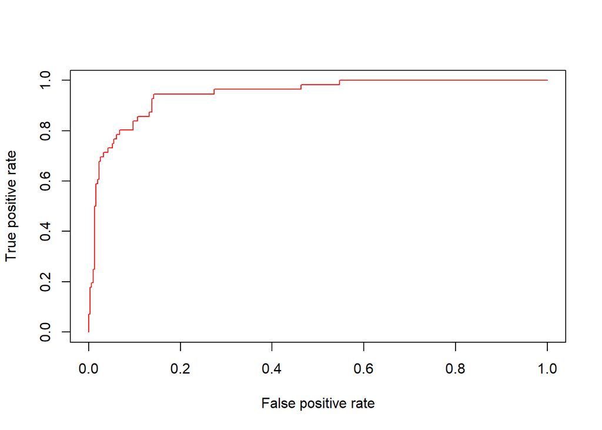

```r
##arguments for pred are model predicted probabilities and response y
pred <- prediction(reduced2$fitted.values, dbt$diagnosis)
#Now, can just copy and paste rest of code
perf <- performance(pred, measure = "tpr", x.measure = "fpr")
plot(perf, col=rainbow(10))
```

```r
#Obtain area under the curve (AUC)
auc.tmp <- performance(pred,"auc");
auc <- as.numeric(auc.tmp@y.values)
auc
```

```
## [1] 0.9459118
```

The high AUC indicates good model discrimination

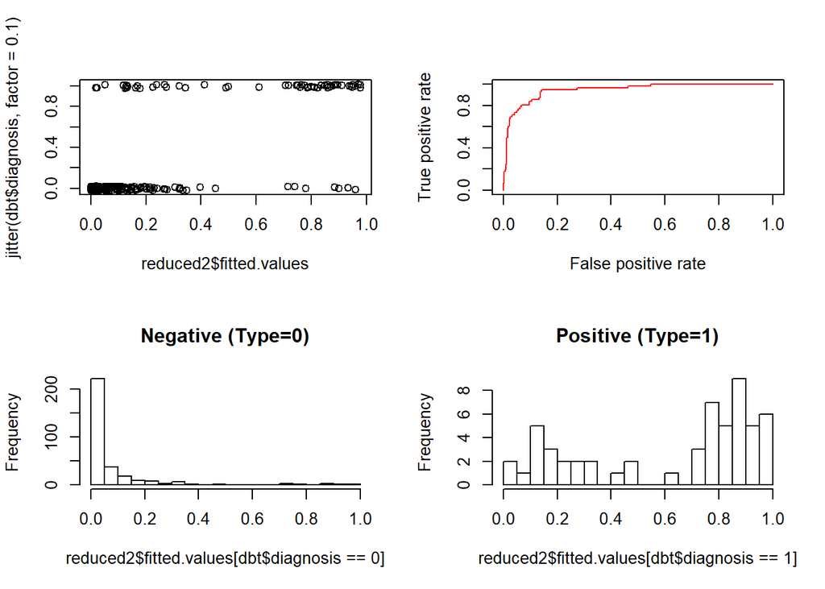

```r
#Plots to summarize model discrimination
par(mfrow=c(2,2))
plot(reduced2$fitted.values,jitter(dbt$diagnosis,factor=0.1))
plot(perf, col=rainbow(10))
hist(reduced2$fitted.values[dbt$diagnosis==0],main="Negative (Type=0)",breaks=20)
hist(reduced2$fitted.values[dbt$diagnosis==1],main="Positive (Type=1)",breaks=20)
```